# Growth Analysis

Julie Mocko

04-10-2018

> **Disclaimer:** *The data for this R Notebook have been purposefully altered for the purposes of display in my portfolio. The original data are sensitive, as the study is ongoing and has not been published yet.*

The purpose of this R Notebook is to investigate differences in mouse growth (weight, length, and BMI) across age (day 1 to day 9) between different genotypes (WT - wildtype (control), Het - heterozygous, KO - knock-out (mutant)), sexes (M, F), and litter sizes (1 - 6 mice).

**Definitions:**

- Genotype - genetic makeup of the mouse, in this case, with reference to a single gene
- WT - wildtype - mouse has two normal copies of the gene
- Het - heterozygous - mouse has one normal copy and one mutated copy of the gene
- KO - knock-out - mouse has two mutated copies of the gene

# 1. Raw Data Import and Transformation/Normalization

First, the raw weight and raw length data is imported, and all of the calculations and transformations are done internally within R to avoid error propagation that is prone to occur in Excel with copying and pasting.

```r
#Load all needed libraries
suppressMessages(library(tidyr))
suppressMessages(library(reshape2))
suppressMessages(library(ggplot2))
suppressMessages(library(grid))
suppressMessages(library(ggsignif))
suppressMessages(library(ggpubr))
suppressMessages(library(dplyr))
suppressMessages(library(plyr))
#Read the csv data file into R
#PC:
RawWeight = read.csv("C:/Users/Julie/Dropbox/Julie's Stuff/Portfolio/Growth/Growth/RawWeight.csv", header = TRUE)
RawLength = read.csv("C:/Users/Julie/Dropbox/Julie's Stuff/Portfolio/Growth/Growth/RawLength.csv", header = TRUE)
#Tidy the RawWeight
RawWeight$Sex[which(RawWeight$Sex == "f")] <- "F"
RawWeight$Sex[which(RawWeight$Sex == "m")] <- "M"
RawWeight$Sex <- factor(RawWeight$Sex, levels = c("F","M"))
RawWeight <- RawWeight[complete.cases(RawWeight$X6),]
names(RawWeight)[1] <- "PupID"
names(RawWeight)[6] <- "1"
names(RawWeight)[7] <- "2"
names(RawWeight)[8] <- "3"
names(RawWeight)[9] <- "4"
names(RawWeight)[10] <- "5"
names(RawWeight)[11] <- "6"
names(RawWeight)[12] <- "7"
names(RawWeight)[13] <- "8"
names(RawWeight)[14] <- "9"
#Tidy the RawLength
RawLength$Sex[which(RawLength$Sex == "f")] <- "F"
RawLength$Sex[which(RawLength$Sex == "m")] <- "M"
RawLength$Sex <- factor(RawLength$Sex, levels = c("F","M"))
RawLength <- RawLength[complete.cases(RawLength$X6),]
names(RawLength)[1] <- "PupID"
names(RawLength)[6] <- "1"
names(RawLength)[7] <- "2"
names(RawLength)[8] <- "3"
names(RawLength)[9] <- "4"
names(RawLength)[10] <- "5"
names(RawLength)[11] <- "6"
names(RawLength)[12] <- "7"
names(RawLength)[13] <- "8"
names(RawLength)[14] <- "9"
#Creating Weight Gain variable
RawWeight$WTGain <- RawWeight$`9`-RawWeight$`1`
RawWeight <- RawWeight[complete.cases(RawWeight$`9`),]
#Creating Length Gain variable
RawLength$LNGain <- RawLength$`9`-RawLength$`1`
RawLength <- RawLength[complete.cases(RawLength$`9`),]
#Transforming wide data to long format and merging datasets
WeightData <- melt(RawWeight, variable.name = "Age", value.name = "Weight",
                   id.vars = c("PupID","Litter", "LitterSize","Geno", "Sex", "WTGain"))
LengthData <- melt(RawLength, variable.name = "Age", value.name = "Length",
                   id.vars = c("PupID","Litter", "LitterSize","Geno", "Sex", "LNGain"))
Data <- merge(WeightData, LengthData, by=c("PupID", "Litter", "Sex", "LitterSize", "Geno", "Age"))
#Creating BMI variable
Data$BMI <- (Data$Weight/((Data$Length*Data$Length)))*1000
#Change all factors into factor data types
Data$PupID <- as.factor(Data$PupID)
Data$LitterSize <- as.factor(Data$LitterSize)
Data$Geno <- as.factor(Data$Geno)
Data$Sex <- as.factor(Data$Sex)
Data$AgeFactor <- as.factor(Data$Age)
Data$Geno <- factor(Data$Geno, levels =c("WT", "Het", "KO"))
#Make data subsets
DataLS2to5 <- Data[which(Data$LitterSize =="2" | Data$LitterSize=="3"|
                           Data$LitterSize=="4"| Data$LitterSize=="5"),]
DataP1 <- Data[which(Data$Age == "1"),]
DataP9 <- Data[which(Data$Age == "9"),]
```

# 2. Data Visualization and Analysis

```r
#Create function to apply the same style to each chart
addtheme <- function(chart, title, subtitle, legend_pos){
  chart +
    labs(title = title, subtitle = subtitle)+
    theme_minimal()+
    theme(panel.grid.major = element_blank(),
          panel.grid.minor = element_blank(),
          panel.border = element_blank(),
          panel.background = element_blank(),
          plot.title = element_text(size = 12, face = "bold"),
          axis.title = element_text(face="bold"),
          axis.text.x = element_text(colour="black", size = 10),
          axis.text.y = element_text(colour="black", size = 10),
          axis.line.x = element_line(size = 0.5, colour = "black"),
          axis.line.y = element_line(size = 0.5, colour = "black"),
          legend.position = legend_pos)
}
#Create a function for generating box plots with my preferred parameters
bp <- function(data, x, y, fill, xaxis, yaxis, ylim, title, subtitle,
               color_name, colors, legend_lab, legend_pos)
{
  chart <- ggplot(data, aes(x=x, y=y, fill = fill))+
    geom_boxplot(alpha=0.7)+
    scale_x_discrete(name=xaxis)+
    scale_y_continuous(name=yaxis, limits = ylim)+
    scale_fill_manual(color_name, values=colors, labels = legend_lab) +
    stat_compare_means(label="p.signif", method="anova", hide.ns=TRUE,
                       label.y = ylim[2], size = signif_size)

  chart <- addtheme(chart,title, subtitle, legend_pos)
}
#Create a function for generating box plots using brewer pallete with my preferred parameters
brewer_bp <- function(data, x, y, fill, xaxis, yaxis, ylim, title, subtitle,
                      color_name, palette = "RdBu", legend_lab, legend_pos){
  chart <- ggplot(data, aes(x=x, y=y, fill = fill))+
    geom_boxplot(alpha=0.7)+
    scale_x_discrete(name=xaxis)+
    scale_y_continuous(name=yaxis, limits = ylim)+
    scale_fill_brewer(color_name, palette = "RdBu", labels = legend_lab)+
    stat_compare_means(label="p.signif", method="anova", hide.ns=TRUE,
                       label.y = ylim[2], size = signif_size)

  chart <- addtheme(chart,title, subtitle, legend_pos)
}
#Create a function for generating density plots
densityplot <- function(data, x, color_group, xaxis, title, subtitle,
                        color_name, colors, legend_lab, legend_pos){
  chart <- ggplot(data, aes(x=x, color = color_group))+
    geom_density(size=1.5)+
    scale_x_continuous(name= xaxis)+
    scale_y_continuous(name="Density")+
    scale_color_manual(color_name, values = colors, labels = legend_lab)

  chart <- addtheme(chart,title, subtitle, legend_pos)
}
#Create a function for generating line plots
lp <- function(data, x, y, xaxis, yaxis, ylim, color, title, subtitle,
               color_name, colors, line_col = "darkred", legend_lab, legend_pos){
  chart <- ggplot(data, aes(x=x, y=y, color = color)) +
    geom_point(size = 3) +
    geom_smooth(method=lm, linetype="dashed", color=line_col, fill="#E8F5FF") +
    scale_x_continuous(name=xaxis)+
    scale_y_continuous(name=yaxis, limits = ylim)+
    scale_color_manual(color_name, values=colors, labels = legend_lab)

  chart <- addtheme(chart,title, subtitle, legend_pos)
}
#Generating custom legends with sample sizes
geno_lab <- c(paste("WT (",count(Data$Geno[which(Data$Geno == "WT" & Data$Age == "9")])[2],")"),
              paste("Het (",count(Data$Geno[which(Data$Geno == "Het" & Data$Age == "9")])[2],")"),
              paste("KO (",count(Data$Geno[which(Data$Geno == "KO" & Data$Age == "9")])[2],")"))
sex_lab <- c(paste("F (",count(Data$Sex[which(Data$Sex == "F" & Data$Age == "9")])[2],")"),
             paste("M (",count(Data$Sex[which(Data$Sex == "M" & Data$Age == "9")])[2],")"))
LS_lab <- c(paste("1 (",count(Data$LitterSize[which(Data$LitterSize == "1"
                                                    & Data$Age == "9")])[2],")"),
            paste("2 (",count(Data$LitterSize[which(Data$LitterSize == "2"
                                                    & Data$Age == "9")])[2],")"),
            paste("3 (",count(Data$LitterSize[which(Data$LitterSize == "3"
                                                    & Data$Age == "9")])[2],")"),
            paste("4 (",count(Data$LitterSize[which(Data$LitterSize == "4"
                                                    & Data$Age == "9")])[2],")"),
            paste("5 (",count(Data$LitterSize[which(Data$LitterSize == "5"
                                                    & Data$Age == "9")])[2],")"),
            paste("6 (",count(Data$LitterSize[which(Data$LitterSize == "6"
                                                     & Data$Age == "9")])[2],")"))
#Common plot parameters:
#Colors for genotypes
geno_colors <- c('#BBBBBB','#78D2FF','#001987')
#Colors for sexes
sex_colors <- c('#BBBBBB','#000000')
#Color of lines
lines <- "#1F3552"
#Size of significance markers
signif_size <- 5
#Custom legend positions
bottom_right <- c(0.8,0.2)
top_right <- c(0.9,0.8)
```

## 2.1 Raw Data

Mice were housed under normal conditions (12hr light/12 hr dark; food ad libidum), and were weighed (g) and length was measured (mm) at nine different time points (ages 1 - 9). Weight gain and length gain were calculated as the difference between measures at age 1 and 9. BMI was calculated as: (weight (g)/ length<sup>2</sup> (mm<sup>2</sup>)) x 1000.

### 2.1.1 Raw Weight Across Age

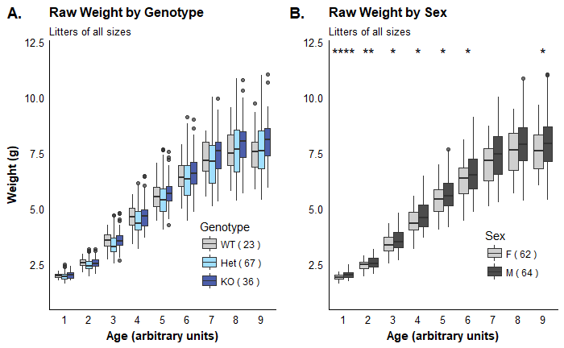

```r
#Boxplot Parameters for Raw Weight
xaxis <- "Age (arbitrary units)"
yaxis <- "Weight (g)"
subtitle <- "Litters of all sizes"
ylim <- c(round(min(Data$Weight)-1),round(max(Data$Weight)+1))
#Boxplot of raw weight across age, divided by genotype
title <- "Raw Weight by Genotype"
plotA <- bp(Data, x=Data$AgeFactor, y=Data$Weight, fill=Data$Geno,
                   xaxis, yaxis, ylim, title, subtitle, color_name = "Genotype",
                   colors = geno_colors, legend_lab = geno_lab, legend_pos = bottom_right)
#Boxplot of raw weight across age, divided by sex
title <- "Raw Weight by Sex"
plotB <- bp(Data, x=Data$AgeFactor, y=Data$Weight, fill=Data$Sex,
                   xaxis, yaxis="", ylim, title, subtitle, color_name = "Sex",
                   colors = sex_colors, legend_lab = sex_lab, legend_pos = bottom_right)
#Boxplot of raw weight across age, divided by litter size
title <- "Raw Weight by Litter Size"
plotC <- brewer_bp(Data, x=Data$AgeFactor, y=Data$Weight, fill=Data$LitterSize,
                   xaxis, yaxis, ylim, title, subtitle, color_name = "Litter Size",
                   legend_lab = LS_lab, legend_pos = "right")
#Arrange boxplots into 3 panels
suppressWarnings(ggarrange(plotA, plotB, labels = c("A.","B."), ncol = 2, nrow = 1))
```

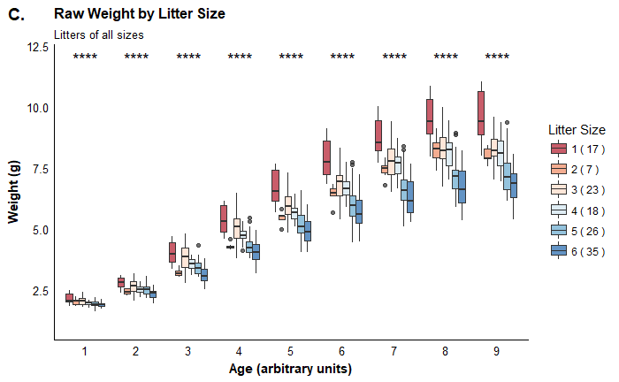

```r
suppressWarnings(ggarrange(plotC, labels = c("C."), ncol = 1, nrow = 1))
```

**Observations**

*Genotype*  
When all litter sizes and both sexes are included, there is no significant effect of genotype on raw weight across age. However, there is a trend of control (WT, *grey*) mice weighing less than mutant (KO, *dark blue*) mice.

*Sex*  
There is a strong effect of mouse sex on growth. On average, males are larger than females.

*Litter Size*  
There is a strong effect of litter size on mouse weight. Mice from larger litters (*blue*) have lower starting weights and grow less across the ages tested as compared to mice from small litters (*red*).

### 2.1.2 Raw Length Across Age

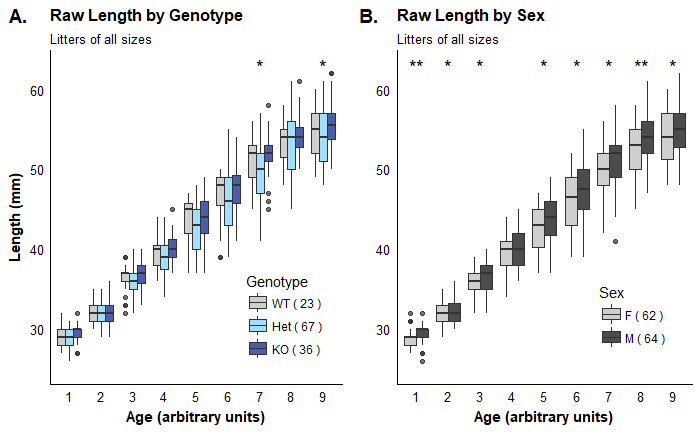

```r
#Boxplot Parameters for Raw Length
xaxis <- "Age (arbitrary units)"
yaxis <- "Length (mm)"
ylim <- c(round(min(DataP1$Length)-1),round(max(DataP9$Length)+1))
#Boxplot of raw Length across age, divided by genotype
title <- "Raw Length by Genotype"
plotA <- bp(Data, x=Data$AgeFactor, y=Data$Length, fill=Data$Geno,
                   xaxis, yaxis, ylim, title, subtitle, color_name = "Genotype",
                   colors = geno_colors, legend_lab = geno_lab, legend_pos = bottom_right)
#Boxplot of raw Length across age, divided by sex
title <- "Raw Length by Sex"
plotB <- bp(Data, x=Data$AgeFactor, y=Data$Length, fill=Data$Sex,
                   xaxis, yaxis="", ylim, title, subtitle, color_name = "Sex",
                   colors = sex_colors, legend_lab = sex_lab, legend_pos = bottom_right)
#Boxplot of raw Length across age, divided by litter size
title <- "Raw Length by Litter Size"
plotC <- brewer_bp(Data, x=Data$AgeFactor, y=Data$Length, fill=Data$LitterSize,
                   xaxis, yaxis, ylim, title, subtitle, color_name = "Litter Size",
                   legend_lab = LS_lab, legend_pos = "right")
#Arrange boxplots into 3 panels
suppressWarnings(ggarrange(plotA, plotB, labels = c("A.","B."), ncol = 2, nrow = 1))
```

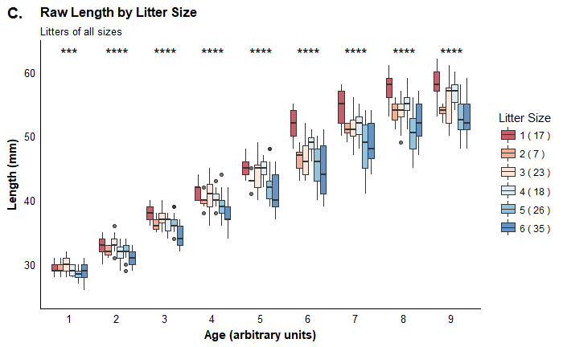

```r
suppressWarnings(ggarrange(plotC, labels = c("C."), ncol = 1, nrow = 1))
```

**Observations**

*Litter Size*  
There is a strong effect of litter size on mouse weight. Mice from larger litters have lower starting weights and grow less across the ages tested as compared to mice from small litters.

### 2.1.3 Raw BMI Across Age

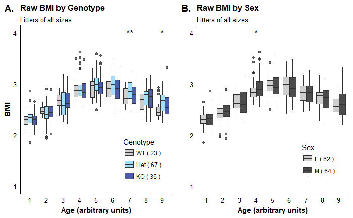

```r
#Boxplot Parameters for Raw BMI
xaxis <- "Age (arbitrary units)"
yaxis <- "BMI"
ylim <- c(round(min(DataP1$BMI)-1),round(max(DataP9$BMI)+1))
#Boxplot of raw BMI across age, divided by genotype
title <- "Raw BMI by Genotype"
plotA <- bp(Data, x=Data$AgeFactor, y=Data$BMI, fill=Data$Geno,
                   xaxis, yaxis, ylim, title, subtitle, color_name = "Genotype",
                   colors = geno_colors, legend_lab = geno_lab, legend_pos = bottom_right)
#Boxplot of raw BMI across age, divided by sex
title <- "Raw BMI by Sex"
plotB <- bp(Data, x=Data$AgeFactor, y=Data$BMI, fill=Data$Sex,
                   xaxis, yaxis="", ylim, title, subtitle, color_name = "Sex",
                   colors = sex_colors, legend_lab = sex_lab, legend_pos = bottom_right)
#Boxplot of raw BMI across age, divided by litter size
title <- "Raw BMI by Litter Size"
plotC <- brewer_bp(Data, x=Data$AgeFactor, y=Data$BMI, fill=Data$LitterSize,
                   xaxis, yaxis, ylim, title, subtitle, color_name = "Litter Size",
                   legend_lab = LS_lab, legend_pos = "right")
#Arrange boxplots into 3 panels
suppressWarnings(ggarrange(plotA, plotB, labels = c("A.","B."), ncol = 2, nrow = 1))
```

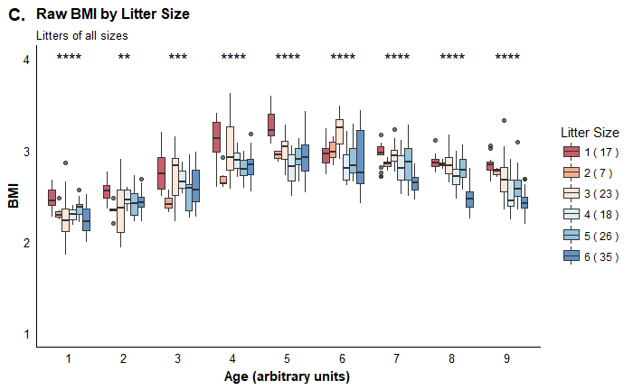

```r
suppressWarnings(ggarrange(plotC, labels = c("C."), ncol = 1, nrow = 1))
```

**Observations**

*Genotype*  
BMI was similar across genotypes at most ages. At age 7 and 9, there was a significant effect of genotype.

*Sex*  
Overall, BMI was similar across sexes at most ages, with the exception of age 4.

*Litter Size*  
There is a strong effect of litter size on mouse BMI. Mice from larger litters have lower BMI across age as compared to mice from small litters.

### 2.1.4 Weight Gain, Length Gain and BMI at Age 9

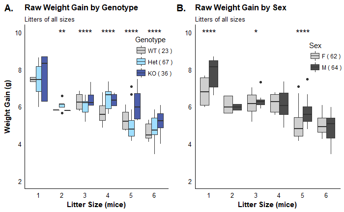

```r
#Boxplot Parameters for Weight Gain
xaxis <- "Litter Size (mice)"
yaxis <- "Weight Gain (g)"
ylim <- c(round(min(Data$WTGain)-1),round(max(Data$WTGain)+1))
#Boxplot of raw weight gain across age, divided by genotype
title <- "Raw Weight Gain by Genotype"
plotA <- bp(Data, x=Data$LitterSize, y=Data$WTGain, fill=Data$Geno,
                   xaxis, yaxis, ylim, title, subtitle, color_name = "Genotype",
                   colors = geno_colors, legend_lab = geno_lab, legend_pos = top_right)
#Boxplot of raw weight gain across age, divided by sex
title <- "Raw Weight Gain by Sex"
plotB <- bp(Data, x=Data$LitterSize, y=Data$WTGain, fill=Data$Sex,
                   xaxis, yaxis="", ylim, title, subtitle, color_name = "Sex",
                   colors = sex_colors, legend_lab = sex_lab, legend_pos = top_right)
#Boxplot Parameters - Boxplots for Length Gain
yaxis <- "Length Gain (mm)"
ylim <- c(round(min(Data$LNGain)-1),40)
#Boxplot of raw length gain across age, divided by genotype
title <- "Raw Length Gain by Genotype"
plotC <- bp(Data, x=Data$LitterSize, y=Data$LNGain, fill=Data$Geno,
                   xaxis, yaxis, ylim, title, subtitle, color_name = "Genotype",
                   colors = geno_colors, legend_lab = geno_lab, legend_pos = top_right)
#Boxplot of raw length gain across age, divided by sex
title <- "Raw Length Gain by Sex"
plotD <- bp(Data, x=Data$LitterSize, y=Data$LNGain, fill=Data$Sex,
                   xaxis, yaxis="", ylim, title, subtitle, color_name = "Sex",
                   colors = sex_colors, legend_lab = sex_lab, legend_pos = top_right)
#Boxplot Parameters - Boxplots for BMI at age 9
yaxis <- "BMI at Age 9"
ylim <- c(2.25,3.5)
#Boxplot of raw BMI at age 9 across age, divided by genotype
title <- "Raw BMI at Age 9 by Genotype"
plotE <- bp(DataP9, x=DataP9$LitterSize, y=DataP9$BMI, fill=DataP9$Geno,
                   xaxis, yaxis, ylim, title, subtitle, color_name = "Genotype",
                   colors = geno_colors, legend_lab = geno_lab, legend_pos = top_right)
#Boxplot of raw BMI at age 9 across age, divided by sex
title <- "Raw BMI at Age 9 by Sex"
plotF <- bp(DataP9, x=DataP9$LitterSize, y=DataP9$BMI, fill=DataP9$Sex,
                   xaxis, yaxis="", ylim, title, subtitle, color_name = "Sex",
                   colors = sex_colors, legend_lab = sex_lab, legend_pos = top_right)
suppressWarnings(ggarrange(plotA, plotB, labels = c("A.","B."), ncol = 2, nrow = 1))
```

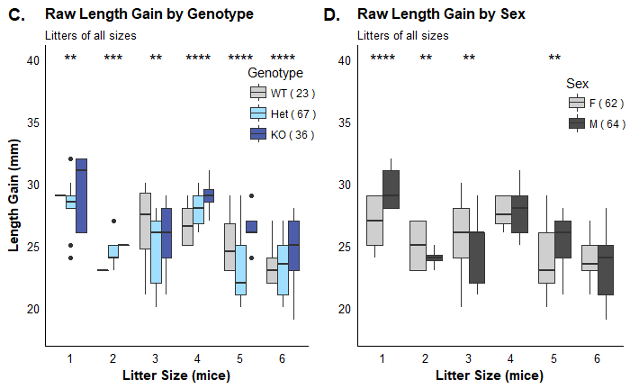

```r
suppressWarnings(ggarrange(plotC, plotD, labels = c("C.","D."), ncol = 2, nrow = 1))
```

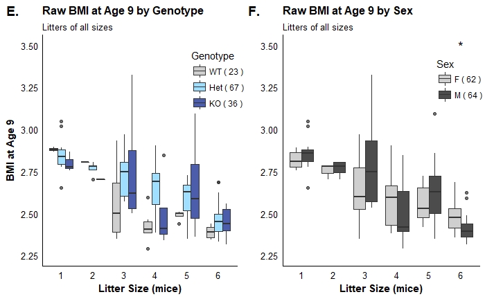

```r
suppressWarnings(ggarrange(plotE, plotF, labels = c("E.","F."), ncol = 2, nrow = 1))
```

**Observations**  
As expected from previous charts, there is a strong effect of litter size on weight gain and length gain. There appears to be a trend of decreasing BMI with increasing litter size, however, this was not found to be significant. This may be due to the fact that weight and length decrease proportionally with litter size, thereby resulting in relatively constant BMI. This also appears to be the case for different genotypes and sexes.

### 2.1.5. Effect of litter size on weight gain and length gain

In addition to an effect of litter size, the boxplots suggest that there may be an effect of genotype, as well as an effect of sex. The weight and length data are approximately normally distributed (see density plots below), and a linear model is fit to the data.

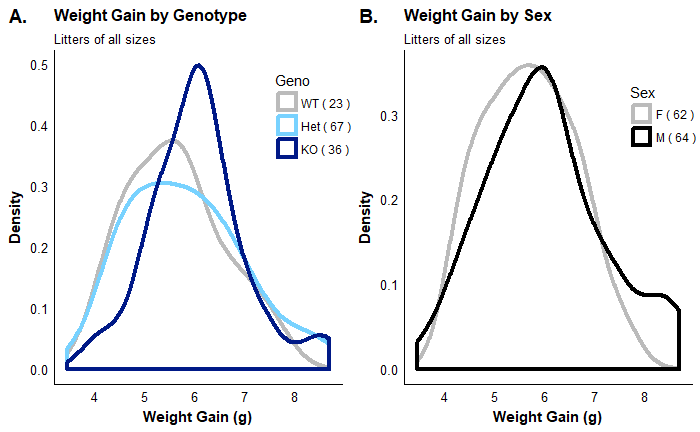

```r
#Density Plots for Weight Gain
xaxis <- "Weight Gain (g)"
title <- "Weight Gain by Genotype"
plotA <- densityplot(DataP9, DataP9$WTGain, color_group = DataP9$Geno, xaxis, title, subtitle, color_name = "Geno", colors = geno_colors, legend_lab = geno_lab, legend_pos = top_right)
title <- "Weight Gain by Sex"
plotB <- densityplot(DataP9, DataP9$WTGain, color_group = DataP9$Sex, xaxis, title, subtitle, color_name = "Sex", colors = sex_colors, legend_lab = sex_lab, legend_pos = top_right)
#Density Plot for Length Gain
xaxis <- "Length Gain (mm)"
title <- "Length Gain by Genotype"
plotC <- densityplot(DataP9, DataP9$LNGain, color_group = DataP9$Geno, xaxis, title, subtitle, color_name = "Geno", colors = geno_colors, legend_lab = geno_lab, legend_pos = top_right)
title <- "Length Gain by Sex"
plotD <- densityplot(DataP9, DataP9$LNGain, color_group = DataP9$Sex, xaxis, title, subtitle, color_name = "Sex", colors = sex_colors, legend_lab = sex_lab, legend_pos = top_right)
suppressWarnings(ggarrange(plotA, plotB, labels = c("A.","B."), ncol = 2, nrow = 1))
```

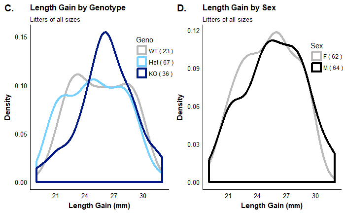

```r
suppressWarnings(ggarrange(plotC, plotD, labels = c("C.","D."), ncol = 2, nrow = 1))
```

```r
#5. Build Linear Model and Check Significance
DataP9$LS_num <- as.numeric(DataP9$LitterSize)
model <- lm(DataP9$WTGain ~ DataP9$LS_num, data=DataP9)
modelSummary <- summary(model)
modelCoeffsWG <- modelSummary$coefficients
beta.estimate <- modelCoeffsWG["DataP9$LS_num", "Estimate"]
std.error <- modelCoeffsWG["DataP9$LS_num", "Std. Error"]
t_value <- beta.estimate/std.error
WGp_value <- format(round(2*pt(-abs(t_value), df=nrow(Data)-2),4), nsmall = 4)
```

*Weight Gain*

The formula y = -0.46x + 7.71 describes the relationship between mouse weight gain (y) and litter size (x). For every extra mouse in a litter, the mouse weight gain from age 1 toa ge 9 is reduced by 0.46g (p = 0.0000).

```r
#5. Build Linear Model and Check Significance
model <- lm(DataP9$LNGain ~ DataP9$LS_num, data=DataP9)
modelSummary <- summary(model)
modelCoeffsLN <- modelSummary$coefficients
beta.estimate <- modelCoeffsLN["DataP9$LS_num", "Estimate"]
std.error <- modelCoeffsLN["DataP9$LS_num", "Std. Error"]
t_value <- beta.estimate/std.error
LNp_value <- format(round(2*pt(-abs(t_value), df=nrow(Data)-2),4), nsmall = 4)
```

*Length Gain*

The formula y = -0.77x + 28.62 describes the relationship between mouse length gain (y) and litter size (x). For every extra mouse in a litter, the mouse length gain from age 1 to age 9 is reduced by 0.77mm (p = 0.0000).

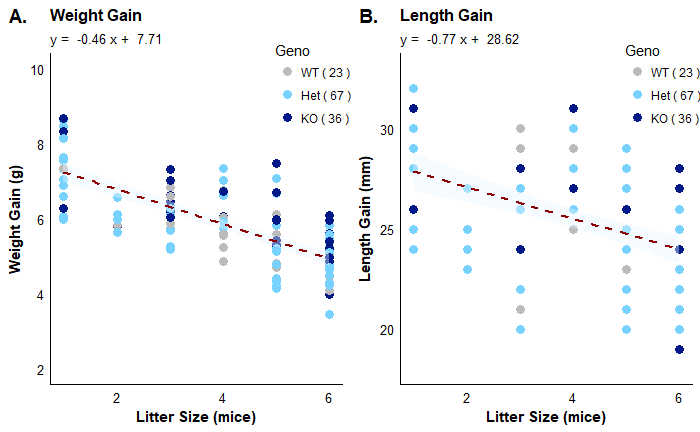

```r
#Scatter and line plot for Weight Gain
xaxis <- "Litter Size (mice)"
yaxis <- "Weight Gain (g)"
ylim <- c(round(min(Data$WTGain)-1),round(max(Data$WTGain)+1))
title <- "Weight Gain"
subtitle <- paste("y = ",round(modelCoeffsWG["DataP9$LS_num", "Estimate"],2),
                  "x + ",round(modelCoeffsWG[1],2))
plotA <- lp(data = DataP9, x = DataP9$LS_num, y = DataP9$WTGain, xaxis, yaxis, ylim, color = DataP9$Geno, title, subtitle, color_name = "Geno", colors = geno_colors, line_col = "darkred", legend_lab = geno_lab, legend_pos = c(0.9,0.9))
#Scatter and line plot for Length Gain
xaxis <- "Litter Size (mice)"
yaxis <- "Length Gain (mm)"
ylim <- c(round(min(Data$LNGain)-1),round(max(Data$LNGain)+1))
title <- "Length Gain"
subtitle <- paste("y = ",round(modelCoeffsLN["DataP9$LS_num", "Estimate"],2),
                  "x + ",round(modelCoeffsLN[1],2))
plotB<- lp(data = DataP9, x = DataP9$LS_num, y = DataP9$LNGain, xaxis, yaxis, ylim, color = DataP9$Geno, title, subtitle, color_name = "Geno", colors = geno_colors, line_col = "darkred", legend_lab = geno_lab, legend_pos = c(0.9,0.9))
suppressWarnings(ggarrange(plotA, plotB, labels = c("A.","B."),ncol = 2, nrow = 1))
```

### 2.1.6 Discussion

In order to account for the effect of litter size, data are normalized within each litter to the average heterozygous measures at age 9 (section 2.2), or at each age (section 2.3). In addition, analyses have been carried out on data from select litter sizes (litter sizes 2-5, section 2.5).

## 2.2 Data Normalized to Average Measures at Age 9 Heterozygous Mice (combined sexes) Within Litter

```r
#Normalization to average age 9 Het within litter:
#Creating a normalized data set, wherein all data has been normalized to the average Het weight at age 9 within litter
#Normalized Weight
for(i in 1:length(levels(Data$Litter))){
  Data[which(Data$Litter == levels(Data$Litter)[i]),"NormWT"]<- Data[which(Data$Litter == levels(Data$Litter)[i]),"Weight"]/mean(Data[which(Data$Geno == "Het" & Data$Age == "9" & Data$Litter == levels(Data$Litter)[i]),"Weight"])
}
#Normalized Weight Gain
for(i in 1:length(levels(Data$Litter))){
  Data[which(Data$Litter == levels(Data$Litter)[i]),"NormWTGain"]<- Data[which(Data$Litter == levels(Data$Litter)[i]),"WTGain"]/mean(Data[which(Data$Geno == "Het" & Data$Age == "9" & Data$Litter == levels(Data$Litter)[i]),"WTGain"])
}
#Normalized Length
for(i in 1:length(levels(Data$Litter))){
  Data[which(Data$Litter == levels(Data$Litter)[i]),"NormLN"]<- Data[which(Data$Litter == levels(Data$Litter)[i]),"Length"]/mean(Data[which(Data$Geno == "Het" & Data$Age == "9" & Data$Litter == levels(Data$Litter)[i]),"Length"])
}
#Normalized Length Gain
for(i in 1:length(levels(Data$Litter))){
  Data[which(Data$Litter == levels(Data$Litter)[i]),"NormLNGain"]<- Data[which(Data$Litter == levels(Data$Litter)[i]),"LNGain"]/mean(Data[which(Data$Geno == "Het" & Data$Age == "9" & Data$Litter == levels(Data$Litter)[i]),"LNGain"])
}
#Normalized BMI
for(i in 1:length(levels(Data$Litter))){
  Data[which(Data$Litter == levels(Data$Litter)[i]),"NormBMI"]<- Data[which(Data$Litter == levels(Data$Litter)[i]),"BMI"]/mean(Data[which(Data$Geno == "Het" & Data$Age == "9" & Data$Litter == levels(Data$Litter)[i]),"BMI"])
}
#Creating subsets by sex
DataF <- Data[which(Data$Sex == "F"),]
DataM <- Data[which(Data$Sex == "M"),]
#Creating subsets by genotype
DataWT <- Data[which(Data$Geno == "WT"),]
DataHet <- Data[which(Data$Geno == "Het"),]
DataKO <- Data[which(Data$Geno == "KO"),]
#Make Age data subsets
DataP5 <- Data[which(Data$Age == "5"),]
DataP6 <- Data[which(Data$Age == "6"),]
DataP7 <- Data[which(Data$Age == "7"),]
DataP8 <- Data[which(Data$Age == "8"),]
DataP9 <- Data[which(Data$Age == "9"),]
```

### 2.2.1 Normalized Weight Across Age

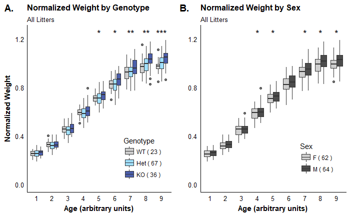

```r
#Boxplot Parameters for Norm Weight
xaxis <- "Age (arbitrary units)"
yaxis <- "Normalized Weight"
subtitle <- "All Litters"
ylim <- c(0,1.25)
#Boxplot of norm weight across age, divided by genotype
title <- "Normalized Weight by Genotype"
plotA <- bp(Data, x=Data$AgeFactor, y=Data$NormWT, fill=Data$Geno,
                   xaxis, yaxis, ylim, title, subtitle, color_name = "Genotype",
                   colors = geno_colors, legend_lab = geno_lab, legend_pos = bottom_right)
#Boxplot of norm weight across age, divided by sex
title <- "Normalized Weight by Sex"
plotB <- bp(Data, x=Data$AgeFactor, y=Data$NormWT, fill=Data$Sex,
                   xaxis, yaxis="", ylim, title, subtitle, color_name = "Sex",
                   colors = sex_colors, legend_lab = sex_lab, legend_pos = bottom_right)
#Boxplot of norm weight across age, divided by litter size
title <- "Normalized Weight by Litter Size"
plotC <- brewer_bp(Data, x=Data$AgeFactor, y=Data$NormWT, fill=Data$LitterSize,
                   xaxis, yaxis, ylim, title, subtitle, color_name = "Litter Size",
                   legend_lab = LS_lab, legend_pos = "right")
#Arrange boxplots into 3 panels
suppressWarnings(ggarrange(plotA, plotB, labels = c("A.","B."), ncol = 2, nrow = 1))
```

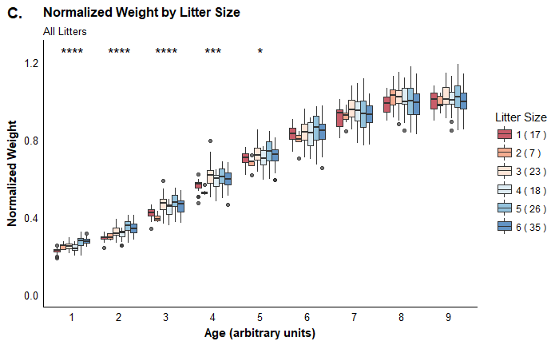

```r
suppressWarnings(ggarrange(plotC, labels = c("C."), ncol = 1, nrow = 1))
```

**Observations**

*Genotype*  
There is a significant effect of genotype on normalized weight. Post-hoc analysis are needed to determine which genotypes are different (see below).

*Sex*  
There is a significant effect of sex on normalized weight. Males are significantly larger than females.

*Litter Size*  
There is a strong effect of litter size, particularly at the youngest ages. This is an artefact of normalization to age 9. As seen in the raw weight data, mice from smaller litters are significantly larger at age 9 than those from larger litters However, the birth weights between mice from litters of different size are more similar than the age 9 weights. Thus, the proportion of age 9 weight at age 1 for a mouse from a small litter is smaller than the same proportion for a mouse from a larger litter. Normalizing to the heterozygous animals at each age will eliminate this artefact. Because this artefact is present for all normalized measures, the “litter size across age”" plots will be omitted for the following metrics.

**Statistical Analyses**  
*Three Way Mixed Model ANOVA*  
*Response Variable: Normalized Weight*  
*Between Subjects Factors: Genotype, Sex*  
*Within Subjects Factors: Age*

```r
#Statistical analysis of normalized weight across age by genotype
model <- aov(Data$NormWT ~Data$Geno*Data$Sex*Data$Age +
                    Error(Data$PupID/Data$Age)+Data$Geno*Data$Sex, data=Data)
summary(model)
```

```
Error: Data$PupID
                    Df Sum Sq Mean Sq F value  Pr(>F)
Data$Geno            2 0.1937 0.09686   5.525 0.00507 **
Data$Sex             1 0.0706 0.07059   4.026 0.04705 *
Data$Geno:Data$Sex   2 0.1418 0.07091   4.045 0.01995 *
Residuals          120 2.1038 0.01753
---
Signif. codes:  0 *** 0.001 ** 0.01 * 0.05 . 0.1   1

Error: Data$PupID:Data$Age
                             Df Sum Sq Mean Sq  F value   Pr(>F)
Data$Age                      8  83.04  10.380 8589.644  < 2e-16 ***
Data$Geno:Data$Age           16   0.08   0.005    4.172 7.38e-08 ***
Data$Sex:Data$Age             8   0.01   0.001    0.993    0.440
Data$Geno:Data$Sex:Data$Age  16   0.03   0.002    1.403    0.132
Residuals                   960   1.16   0.001
---
Signif. codes:  0 *** 0.001 ** 0.01 * 0.05 . 0.1   1
```

There is a significant interaction between genotype and age (p <0.0001), as well as a significant interaction of genotype and sex (p = 0.02). The interaction between genotype and sex may be best described using aggragate weight measures (like weight gain or weight at age 9), rather than average across age.

#### *Post-Hoc: Tukey’s Honestly Significant Difference - Genotype and Age*

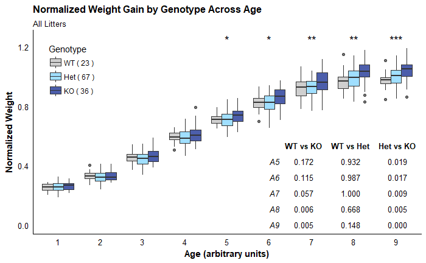

```r
#Posthoc TukeyHSD - Genotype at P6 - P9
mod <- TukeyHSD(aov(DataP5$NormWT ~DataP5$Geno, data = DataP5), ordered = TRUE)
P5geno <- mod$`DataP5$Geno`
mod <- TukeyHSD(aov(DataP6$NormWT ~DataP6$Geno, data = DataP6), ordered = TRUE)
P6geno <- mod$`DataP6$Geno`
mod <- TukeyHSD(aov(DataP7$NormWT ~DataP7$Geno, data = DataP7), ordered = TRUE)
P7geno <- mod$`DataP7$Geno`
mod <- TukeyHSD(aov(DataP8$NormWT ~DataP8$Geno, data = DataP8), ordered = TRUE)
P8geno <- mod$`DataP8$Geno`
mod <- TukeyHSD(aov(DataP9$NormWT ~DataP9$Geno, data = DataP9), ordered = TRUE)
P9geno <- mod$`DataP9$Geno`
Het_KO <- c(A5 = P5geno[2,4], A6 = P6geno[2,4], A7 = P7geno[2,4], A8 = P8geno[2,4], A9 =P9geno[2,4])
WT_KO <- c(A5 = P5geno[3,4], A6 = P6geno[3,4], A7 = P7geno[3,4], A8 = P8geno[3,4],A9 =P9geno[3,4])
WT_Het <- c(A5 = P5geno[1,4], A6 = P6geno[1,4], A7 = P7geno[1,4], A8 = P8geno[1,4],A9 =P9geno[1,4])
multicomp <- data.frame(WT_KO,WT_Het,Het_KO)
plotA <- bp(Data, x=Data$AgeFactor, y=Data$NormWT, fill=Data$Geno,
                   xaxis, yaxis, ylim, title = "Normalized Weight Gain by Genotype Across Age", subtitle, color_name = "Genotype",
                   colors = geno_colors, legend_lab = geno_lab, legend_pos = c(0.1,0.8))
tableB <- ggtexttable(format(round(multicomp,3), nsmall = 3),
            cols = c("WT vs KO", "WT vs Het", "Het vs KO"),
            theme = ttheme("blank", base_size = 10))
plotA + annotation_custom(ggplotGrob(tableB), xmax = 15, ymax = 0.6)
```

### 2.2.2 Normalized Length Across Age

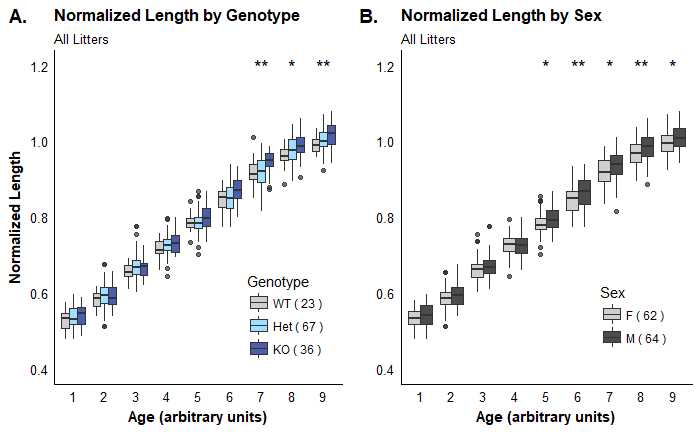

```r
#Boxplot Parameters for Norm Length
xaxis <- "Age (arbitrary units)"
yaxis <- "Normalized Length"
ylim <- c(0.4,1.2)
#Boxplot of norm Length across age, divided by genotype
title <- "Normalized Length by Genotype"
plotA <- bp(Data, x=Data$AgeFactor, y=Data$NormLN, fill=Data$Geno,
                   xaxis, yaxis, ylim, title, subtitle, color_name = "Genotype",
                   colors = geno_colors, legend_lab = geno_lab, legend_pos = bottom_right)
#Boxplot of norm Length across age, divided by sex
title <- "Normalized Length by Sex"
plotB <- bp(Data, x=Data$AgeFactor, y=Data$NormLN, fill=Data$Sex,
                   xaxis, yaxis="", ylim, title, subtitle, color_name = "Sex",
                   colors = sex_colors, legend_lab = sex_lab, legend_pos = bottom_right)
#Arrange boxplots into 3 panels
suppressWarnings(ggarrange(plotA, plotB, labels = c("A.","B."), ncol = 2, nrow = 1))
```

**Observations**

*Genotype*  
There is a significant difference in normalized mouse length between genotypes.

*Sex*  
Similarly to normalized mouse weight, normalized mouse length shows a strong effect of mouse sex. On average, male mice were longer than female mice.

**Statistical Analyses**  
*Three Way Mixed Model ANOVA*  
*Response Variable: Normalized Length*  
*Between Subjects Factors: Genotype, Sex*  
*Within Subjects Factors: Age*

```r
#Statistical analysis of normalized length across age by genotype
model <- aov(Data$NormLN ~Data$Geno*Data$Sex*Data$Age +
                    Error(Data$PupID/Data$Age)+Data$Geno*Data$Sex, data=Data)
```

```
Error() model is singular
```

```r
summary(model)
```

```
Error: Data$PupID
                             Df Sum Sq  Mean Sq F value  Pr(>F)
Data$Geno                     2 0.0424 0.021176   5.658 0.00453 **
Data$Sex                      1 0.0303 0.030313   8.100 0.00524 **
Data$Age                      1 0.0011 0.001147   0.307 0.58091
Data$Geno:Data$Sex            2 0.0246 0.012318   3.291 0.04073 *
Data$Geno:Data$Age            2 0.0002 0.000099   0.026 0.97386
Data$Sex:Data$Age             1 0.0011 0.001055   0.282 0.59640
Data$Geno:Data$Sex:Data$Age   1 0.0025 0.002476   0.662 0.41767
Residuals                   115 0.4304 0.003743
---
Signif. codes:  0 *** 0.001 ** 0.01 * 0.05 . 0.1   1

Error: Data$PupID:Data$Age
                             Df Sum Sq Mean Sq  F value Pr(>F)
Data$Age                      8 28.574   3.572 5082.374 <2e-16 ***
Data$Geno:Data$Age           16  0.020   0.001    1.772 0.0303 *
Data$Sex:Data$Age             8  0.006   0.001    1.115 0.3505
Data$Geno:Data$Sex:Data$Age  16  0.009   0.001    0.777 0.7128
Residuals                   952  0.669   0.001
---
Signif. codes:  0 *** 0.001 ** 0.01 * 0.05 . 0.1   1
```

There is a significant interaction between age and genotype (p = 0.03). There is also a significant interaction between genotype and sex (p = 0.04), and this interaction may be best described using aggragate length measures (like length gain orage 9 length), rather than average across age.

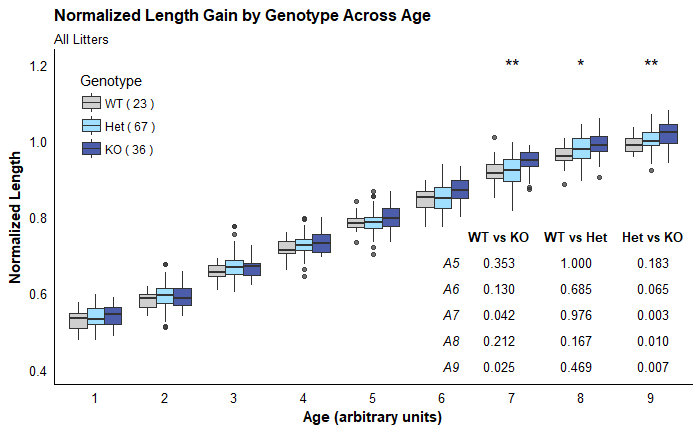

```r
#Posthoc TukeyHSD - Genotype at P5 - P9
mod <- TukeyHSD(aov(DataP5$NormLN ~DataP5$Geno, data = DataP5), ordered = TRUE)
P5geno <- mod$`DataP5$Geno`
mod <- TukeyHSD(aov(DataP6$NormLN ~DataP6$Geno, data = DataP6), ordered = TRUE)
P6geno <- mod$`DataP6$Geno`
mod <- TukeyHSD(aov(DataP7$NormLN ~DataP7$Geno, data = DataP7), ordered = TRUE)
P7geno <- mod$`DataP7$Geno`
mod <- TukeyHSD(aov(DataP8$NormLN ~DataP8$Geno, data = DataP8), ordered = TRUE)
P8geno <- mod$`DataP8$Geno`
mod <- TukeyHSD(aov(DataP9$NormLN ~DataP9$Geno, data = DataP9), ordered = TRUE)
P9geno <- mod$`DataP9$Geno`
Het_KO <- c(A5 = P5geno[2,4], A6 = P6geno[2,4], A7 = P7geno[2,4], A8 = P8geno[2,4], A9 =P9geno[2,4])
WT_KO <- c(A5 = P5geno[3,4], A6 = P6geno[3,4], A7 = P7geno[3,4], A8 = P8geno[3,4],A9 =P9geno[3,4])
WT_Het <- c(A5 = P5geno[1,4], A6 = P6geno[1,4], A7 = P7geno[1,4], A8 = P8geno[1,4],A9 =P9geno[1,4])
multicomp <- data.frame(WT_KO,WT_Het,Het_KO)
plotA <- bp(Data, x=Data$AgeFactor, y=Data$NormLN, fill=Data$Geno,
                   xaxis, yaxis, ylim, title = "Normalized Length Gain by Genotype Across Age", subtitle, color_name = "Genotype",
                   colors = geno_colors, legend_lab = geno_lab, legend_pos = c(0.1,0.8))
tableB <- ggtexttable(format(round(multicomp,3), nsmall = 3),
            cols = c("WT vs KO", "WT vs Het", "Het vs KO"),
            theme = ttheme("blank", base_size = 10))
suppressMessages(plotA + annotation_custom(ggplotGrob(tableB), xmax = 15, ymax = 0.8))
```

Post-hoc analyses reveal that mutant mice (KO, *dark blue*) are significantly longer than wildtype (WT, *grey*, age 7 and 9) and heterozygous mice (Het, *light blue*, age 7 to 9). There is no significant difference in weight between heterogygous and wildtype mice at any age.

### 2.2.3 Normalized BMI Across Age

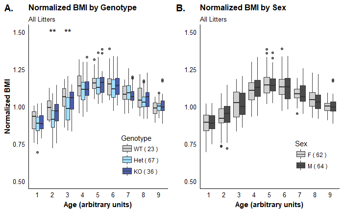

```r
#Boxplot Parameters for Norm BMI
xaxis <- "Age (arbitrary units)"
yaxis <- "Normalized BMI"
ylim <- c(0.5, 1.5)
#Boxplot of norm BMI across age, divided by genotype
title <- "Normalized BMI by Genotype"
plotA <- bp(Data, x=Data$AgeFactor, y=Data$NormBMI, fill=Data$Geno,
                   xaxis, yaxis, ylim, title, subtitle, color_name = "Genotype",
                   colors = geno_colors, legend_lab = geno_lab, legend_pos = bottom_right)
#Boxplot of norm BMI across age, divided by sex
title <- "Normalized BMI by Sex"
plotB <- bp(Data, x=Data$AgeFactor, y=Data$NormBMI, fill=Data$Sex,
                   xaxis, yaxis="", ylim, title, subtitle, color_name = "Sex",
                   colors = sex_colors, legend_lab = sex_lab, legend_pos = bottom_right)
#Arrange boxplots into 3 panels
suppressWarnings(ggarrange(plotA, plotB, labels = c("A.","B."), ncol = 2, nrow = 1))
```

**Observations**

*Genotype*  
BMI are similar across genotypes at most ages.

*Sex*  
There are no differences in BMI between female and male mice.

```r
#Statistical analysis of normalized length across age by genotype
model <- aov(Data$NormBMI ~Data$Geno*Data$Sex*Data$Age +
                    Error(Data$PupID/(Data$Age))+Data$Geno*Data$Sex, data=Data)
```

```
Error() model is singular
```

```r
summary(model)
```

```
Error: Data$PupID
                             Df Sum Sq Mean Sq F value Pr(>F)
Data$Geno                     2 0.1203 0.06013   2.809 0.0644 .
Data$Sex                      1 0.0009 0.00087   0.040 0.8409
Data$Age                      1 0.0001 0.00007   0.003 0.9556
Data$Geno:Data$Sex            2 0.0503 0.02516   1.175 0.3124
Data$Geno:Data$Age            2 0.0137 0.00683   0.319 0.7273
Data$Sex:Data$Age             1 0.0496 0.04964   2.319 0.1306
Data$Geno:Data$Sex:Data$Age   1 0.0018 0.00183   0.085 0.7707
Residuals                   115 2.4622 0.02141
---
Signif. codes:  0 *** 0.001 ** 0.01 * 0.05 . 0.1   1

Error: Data$PupID:Data$Age
                             Df Sum Sq Mean Sq F value Pr(>F)
Data$Age                      8  7.887  0.9858 258.672 <2e-16 ***
Data$Geno:Data$Age           16  0.116  0.0073   1.902 0.0171 *
Data$Sex:Data$Age             8  0.042  0.0053   1.380 0.2011
Data$Geno:Data$Sex:Data$Age  16  0.094  0.0059   1.536 0.0804 .
Residuals                   952  3.628  0.0038
---
Signif. codes:  0 *** 0.001 ** 0.01 * 0.05 . 0.1   1
```

There is a significant interaction between genotype and age (p = 0.02). This is likely driven by differences seen at the earliest ages tested, because these ages are most susceptible to litter size effects/artefacts from normalization.

### 2.2.4 Normalized Weight Gain, Normalized Length Gain and Normalized BMI at age 9 Across Litter Size

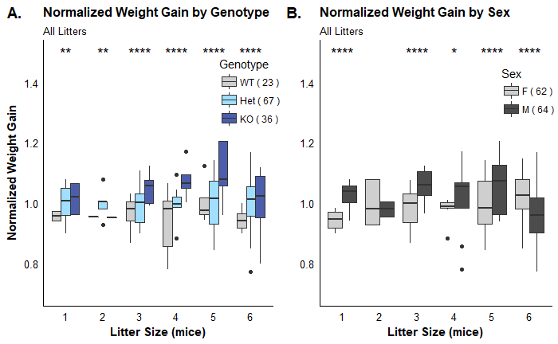

```r
#Boxplot Parameters for Normalized Weight Gain
xaxis <- "Litter Size (mice)"
yaxis <- "Normalized Weight Gain"
ylim <- c(0.7,1.5)
#Boxplot of norm weight gain across age, divided by genotype
title <- "Normalized Weight Gain by Genotype"
plotA <- bp(Data, x=Data$LitterSize, y=Data$NormWTGain, fill=Data$Geno,
                   xaxis, yaxis, ylim, title, subtitle, color_name = "Genotype",
                   colors = geno_colors, legend_lab = geno_lab, legend_pos = top_right)
#Boxplot of norm weight gain across age, divided by sex
title <- "Normalized Weight Gain by Sex"
plotB <- bp(Data, x=Data$LitterSize, y=Data$NormWTGain, fill=Data$Sex,
                   xaxis, yaxis="", ylim, title, subtitle, color_name = "Sex",
                   colors = sex_colors, legend_lab = sex_lab, legend_pos = top_right)
#Boxplot Parameters - Boxplots for Length Gain
yaxis <- "Normalized Length Gain"
ylim <- c(0.7,1.5)
#Boxplot of norm length gain across age, divided by genotype
title <- "Normalized Length Gain by Genotype"
plotC <- bp(Data, x=Data$LitterSize, y=Data$NormLNGain, fill=Data$Geno,
                   xaxis, yaxis, ylim, title, subtitle, color_name = "Genotype",
                   colors = geno_colors, legend_lab = geno_lab, legend_pos = top_right)
#Boxplot of norm length gain across age, divided by sex
title <- "Normalized Length Gain by Sex"
plotD <- bp(Data, x=Data$LitterSize, y=Data$NormLNGain, fill=Data$Sex,
                   xaxis, yaxis="", ylim, title, subtitle, color_name = "Sex",
                   colors = sex_colors, legend_lab = sex_lab, legend_pos = top_right)
#Boxplot Parameters - Boxplots for BMI atage 9
yaxis <- "Normalized BMI at age 9"
ylim <- c(round(min(DataP9$BMI)),round(max(DataP9$BMI)))
#Boxplot of norm BMI at age 9 across age, divided by genotype
title <- "Normalized BMI at age 9 by Genotype"
plotE <- bp(DataP9, x=DataP9$LitterSize, y=DataP9$BMI, fill=DataP9$Geno,
                   xaxis, yaxis, ylim, title, subtitle, color_name = "Genotype",
                   colors = geno_colors, legend_lab = geno_lab, legend_pos = c(0.2,0.2))
#Boxplot of norm BMI at age 9 across age, divided by sex
title <- "Normalized BMI at age 9 by Sex"
plotF <- bp(DataP9, x=DataP9$LitterSize, y=DataP9$BMI, fill=DataP9$Sex,
                   xaxis, yaxis="", ylim, title, subtitle, color_name = "Sex",
                   colors = sex_colors, legend_lab = sex_lab, legend_pos = c(0.2,0.2))
suppressWarnings(ggarrange(plotA, plotB, labels = c("A.","B."), ncol = 2, nrow = 1))
```

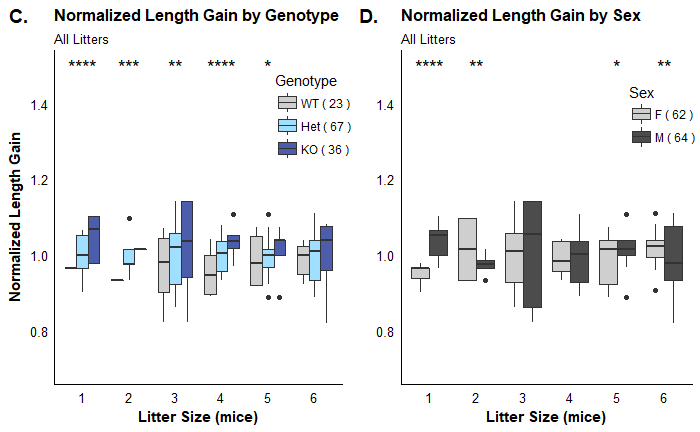

```r
suppressWarnings(ggarrange(plotC, plotD, labels = c("C.","D."), ncol = 2, nrow = 1))
```

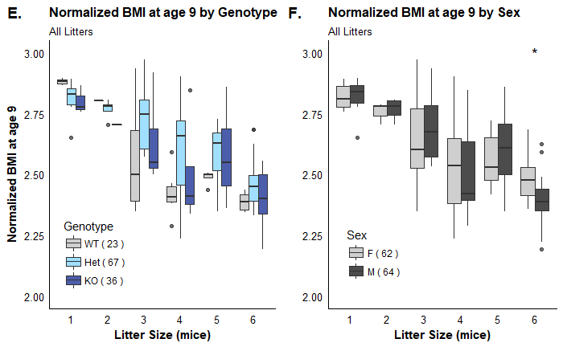

```r
suppressWarnings(ggarrange(plotE, plotF, labels = c("E.","F."), ncol = 2, nrow = 1))
```

**Observations**  
There is a strong effect of genotype and sex for both weight gain and length gain. Interestingly, despite normalization, there is a clear difference in normalized BMI at age 9 between the different litter sizes.

### 2.2.5 Statistical Analysis of Normalized Weight Gain

*Two Way ANOVA*  
*Response Variable: Normalized Weight Gain*  
*Between Subjects Factors: Genotype, Sex*

```r
#Statistical analysis of normalized weight gain by genotype and sex
model <- aov(Data$NormWTGain ~Data$Geno*Data$Sex, data=Data)
summary(model)
```

```
                     Df Sum Sq Mean Sq F value   Pr(>F)
Data$Geno             2  0.914  0.4569   83.25  < 2e-16 ***
Data$Sex              1  0.079  0.0788   14.35  0.00016 ***
Data$Geno:Data$Sex    2  0.337  0.1683   30.66 1.08e-13 ***
Residuals          1128  6.191  0.0055
---
Signif. codes:  0 *** 0.001 ** 0.01 * 0.05 . 0.1   1
```

#### *Post-Hoc: Tukey’s Honestly Significant Difference - Genotype and Sex*

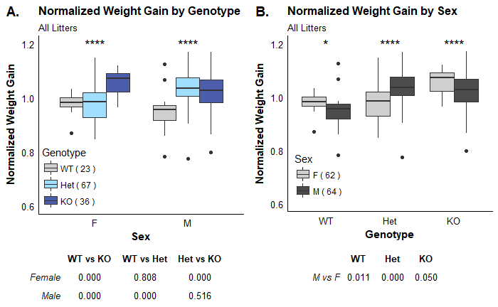

```r
#Posthoc TukeyHSD - Sex for each genotype
mod <- TukeyHSD(aov(DataF$NormWTGain ~ DataF$Geno, data = DataF), ordered = TRUE)
Fgeno <- mod$`DataF$Geno`
mod <- TukeyHSD(aov(DataM$NormWTGain ~ DataM$Geno, data = DataM), ordered = TRUE)
Mgeno <- mod$`DataM$Geno`
WT_KO <- c(Female = Fgeno[2,4], Male = Mgeno[2,4])
Het_KO <- c(Female = Fgeno[3,4], Male = Mgeno[3,4])
WT_Het <- c(Female = Fgeno[1,4], Male = Mgeno[1,4])
multicomp <- data.frame(WT_KO,WT_Het,Het_KO)
xaxis <- "Sex"
yaxis <- "Normalized Weight Gain"
ylim <- c(0.6,1.2)
title <- "Normalized Weight Gain by Genotype"
plotA <- bp(Data, x=Data$Sex, y=Data$NormWTGain, fill=Data$Geno,
                   xaxis, yaxis, ylim, title, subtitle, color_name = "Genotype",
                   colors = geno_colors, legend_lab = geno_lab, legend_pos = c(0.15,0.2))
tableB <- ggtexttable(format(round(multicomp,3), nsmall = 3),
            cols = c("WT vs KO", "WT vs Het", "Het vs KO"),
            theme = ttheme("blank", base_size = 10))
#Posthoc TukeyHSD - Genotype for each sex
mod <- TukeyHSD(aov(DataWT$NormWTGain ~ DataWT$Sex, data = DataWT), ordered = TRUE)
WTgeno <- mod$`DataWT$Sex`
mod <- TukeyHSD(aov(DataHet$NormWTGain ~ DataHet$Sex, data = DataHet), ordered = TRUE)
Hetgeno <- mod$`DataHet$Sex`
mod <- TukeyHSD(aov(DataKO$NormWTGain ~ DataKO$Sex, data = DataKO), ordered = TRUE)
KOgeno <- mod$`DataKO$Sex`
M_F <- c(WT = WTgeno[1,4], Het = Hetgeno[1,4], KO = KOgeno[1,4])
multicomp <- t(format(round(data.frame(M_F),3), nsmall = 3))
multicomp <- rbind(multicomp, c(WT = "", Het = "", KO = ""))
xaxis <- "Genotype"
title <- "Normalized Weight Gain by Sex"
plotC <- bp(Data, x=Data$Geno, y=Data$NormWTGain, fill=Data$Sex,
                   xaxis, yaxis, ylim, title, subtitle, color_name = "Sex",
                   colors = sex_colors, legend_lab = sex_lab, legend_pos = c(0.15,0.2))
tableD <- ggtexttable(multicomp,
            cols = c("WT", "Het", "KO"),
            rows = c("M vs F",""),
            theme = ttheme("blank", base_size = 10))
suppressWarnings(ggarrange(plotA, plotC, tableB, tableD, labels = c("A.","B."),
                           ncol = 2, nrow = 2, heights = c(4,1)))
```

**Normalized Weight Gain - Effect of Genotype by Sex**  
For female mice, wildtype (WT, *grey*) and heterozygous (Het, *light blue*) mice gain significantly less weight than mutant mice (KO, *dark blue*; p < 0.0001). Female wildtype and heterozygous mice and not different from one another.

For male mice, wildtype (WT, *grey*) mice gain significantly less weight than either heterozygous (Het) or mutant (KO) mice (p < 0.0001). Male heterozygous and mutant mice are not different from one another.

### 2.2.6 Statistical Analysis of Normalized Length Gain

*Two Way ANOVA*  
*Response Variable: Normalized Length Gain*  
*Between Subjects Factors: Genotype, Sex*

```r
#Statistical analysis of normalized length gain by genotype and sex
model <- aov(Data$NormLNGain ~Data$Geno*Data$Sex, data=Data)
summary(model)
```

```
                     Df Sum Sq Mean Sq F value Pr(>F)
Data$Geno             2  0.342 0.17077  38.435 <2e-16 ***
Data$Sex              1  0.003 0.00347   0.782  0.377
Data$Geno:Data$Sex    2  0.346 0.17317  38.975 <2e-16 ***
Residuals          1128  5.012 0.00444
---
Signif. codes:  0 *** 0.001 ** 0.01 * 0.05 . 0.1   1
```

There is a significant interaction between genotype and sex (p < 0.0001).

#### *Post-Hoc: Tukey’s Honestly Significant Difference - Genotype and Sex*

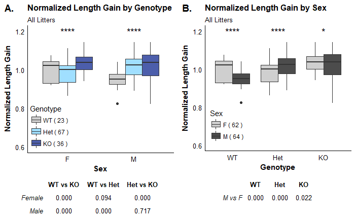

```r
#Posthoc TukeyHSD - Sex for each genotype
mod <- TukeyHSD(aov(DataF$NormLNGain ~ DataF$Geno, data = DataF), ordered = TRUE)
Fgeno <- mod$`DataF$Geno`
mod <- TukeyHSD(aov(DataM$NormLNGain ~ DataM$Geno, data = DataM), ordered = TRUE)
Mgeno <- mod$`DataM$Geno`
WT_KO <- c(Female = Fgeno[2,4], Male = Mgeno[2,4])
Het_KO <- c(Female = Fgeno[3,4], Male = Mgeno[3,4])
WT_Het <- c(Female = Fgeno[1,4], Male = Mgeno[1,4])
multicomp <- data.frame(WT_KO,WT_Het,Het_KO)
xaxis <- "Sex"
yaxis <- "Normalized Length Gain"
ylim <- c(0.6,1.2)
title <- "Normalized Length Gain by Genotype"
plotA <- bp(Data, x=Data$Sex, y=Data$NormLNGain, fill=Data$Geno,
                   xaxis, yaxis, ylim, title, subtitle, color_name = "Genotype",
                   colors = geno_colors, legend_lab = geno_lab, legend_pos = c(0.15,0.2))
tableB <- ggtexttable(format(round(multicomp,3), nsmall = 3),
            cols = c("WT vs KO", "WT vs Het", "Het vs KO"),
            theme = ttheme("blank", base_size = 10))
#Posthoc TukeyHSD - Genotype for each sex
mod <- TukeyHSD(aov(DataWT$NormLNGain ~ DataWT$Sex, data = DataWT), ordered = TRUE)
WTgeno <- mod$`DataWT$Sex`
mod <- TukeyHSD(aov(DataHet$NormLNGain ~ DataHet$Sex, data = DataHet), ordered = TRUE)
Hetgeno <- mod$`DataHet$Sex`
mod <- TukeyHSD(aov(DataKO$NormLNGain ~ DataKO$Sex, data = DataKO), ordered = TRUE)
KOgeno <- mod$`DataKO$Sex`
M_F <- c(WT = WTgeno[1,4], Het = Hetgeno[1,4], KO = KOgeno[1,4])
multicomp <- t(format(round(data.frame(M_F),3), nsmall = 3))
multicomp <- rbind(multicomp, c(WT = "", Het = "", KO = ""))
xaxis <- "Genotype"
title <- "Normalized Length Gain by Sex"
plotC <- bp(Data, x=Data$Geno, y=Data$NormLNGain, fill=Data$Sex,
                   xaxis, yaxis, ylim, title, subtitle, color_name = "Sex",
                   colors = sex_colors, legend_lab = sex_lab, legend_pos = c(0.15,0.2))
tableD <- ggtexttable(multicomp,
            cols = c("WT", "Het", "KO"),
            rows = c("M vs F",""),
            theme = ttheme("blank", base_size = 10))
suppressWarnings(ggarrange(plotA, plotC, tableB, tableD, labels = c("A.","B."),
                           ncol = 2, nrow = 2, heights = c(4,1)))
```

**Normalized Length Gain - Effect of Genotype by Sex**  
For female mice, wildtype (WT, *grey*) and heterozygous (Het, *light blue*) mice gain significantly less length than mutant mice (KO, *dark blue*; p < 0.0001). Female wildtype and heterozygous mice and not different from one another (p = 0.094), however, there is a trend for heterozygous female mice to gain the least length.

For male mice, wildtype (WT, *grey*) mice gain significantly less length than either heterozygous (Het) or mutant (KO) mice (p < 0.0001). Male heterozygous and mutant mice are not different from one another.

**Normalized Length Gain - Effect of Sex by Genotype**  
For wildtype and mutant mice, females gain significantly more length than males (p < 0.05).  
For heterozygous mice, males gain significantly more length than females (p < 0.0001).

### 2.2.7 Statistical Analysis of Normalized BMI at age 9

*Two Way ANOVA*  
*Response Variable: Normalized BMI at age 9*  
*Between Subjects Factors: Genotype, Sex*

```r
#Statistical analysis of normalized BMI at age 9 genotype
model <- aov(DataP9$NormBMI ~DataP9$Geno*DataP9$Sex, data=DataP9)
summary(model)
```

```
                        Df  Sum Sq  Mean Sq F value Pr(>F)
DataP9$Geno              2 0.00501 0.002507   1.095  0.338
DataP9$Sex               1 0.00034 0.000341   0.149  0.700
DataP9$Geno:DataP9$Sex   2 0.00106 0.000528   0.231  0.794
Residuals              120 0.27463 0.002289
```

There are no significant differences between groups for normalized BMI at age 9. This suggests proportional growth in weight and length in all mice studied.

## 2.3 Data Normalized to Average Heterozygous Mice Within Litter At Each Age

The purpose of this normalization is to attempt to eliminate the effect of litter size (particularly at younger ages) on the measurements, thereby allowing pooling of the data across litter size without some of the confounding effects of litter size.

However, as the reader will see, this method of normalization made the data much less interpretable, and eliminated the clear differences between genotypes seen with normalization to the average heterozygous measures at age 9 within each litter.

```r
#Normalization:
Data$AgeNum <- as.numeric(Data$Age)
#Creating a normalized data set, wherein all data has been normalized to the average Het weight at each age within litter
#Normalized Weight
for(i in 1:length(levels(Data$Litter))){
  for(j in 1:length(levels(Data$Age))){
    Data[which(Data$Litter == levels(Data$Litter)[i]),"NormAtAgeWT"]<-
      Data[which(Data$Litter == levels(Data$Litter)[i] & Data$AgeNum == j),"Weight"]/
      mean(Data[which(Data$Geno == "Het" & Data$AgeNum == j & Data$Litter == levels(Data$Litter)[i]),"Weight"])
  }
}
#Normalized Weight Gain
for(i in 1:length(levels(Data$Litter))){
  for(j in 1:length(levels(Data$Age))){
    Data[which(Data$Litter == levels(Data$Litter)[i]),"NormAtAgeWTGain"]<-
      Data[which(Data$Litter == levels(Data$Litter)[i] & Data$AgeNum == j),"WTGain"]/
      mean(Data[which(Data$Geno == "Het" & Data$AgeNum == j & Data$Litter == levels(Data$Litter)[i]),"WTGain"])
  }
}
#Normalized Length
for(i in 1:length(levels(Data$Litter))){
  for(j in 1:length(levels(Data$Age))){
    Data[which(Data$Litter == levels(Data$Litter)[i]),"NormAtAgeLN"]<-
      Data[which(Data$Litter == levels(Data$Litter)[i] & Data$AgeNum == j),"Length"]/
      mean(Data[which(Data$Geno == "Het" & Data$AgeNum == j & Data$Litter == levels(Data$Litter)[i]),"Length"])
  }
}
#Normalized Length Gain
for(i in 1:length(levels(Data$Litter))){
  for(j in 1:length(levels(Data$Age))){
    Data[which(Data$Litter == levels(Data$Litter)[i]),"NormAtAgeLNGain"]<-
      Data[which(Data$Litter == levels(Data$Litter)[i] & Data$AgeNum == j),"LNGain"]/
      mean(Data[which(Data$Geno == "Het" & Data$AgeNum == j & Data$Litter == levels(Data$Litter)[i]),"LNGain"])
  }
}
#Normalized BMI
for(i in 1:length(levels(Data$Litter))){
  for(j in 1:length(levels(Data$Age))){
    Data[which(Data$Litter == levels(Data$Litter)[i]),"NormAtAgeBMI"]<-
      Data[which(Data$Litter == levels(Data$Litter)[i] & Data$AgeNum == j),"BMI"]/
      mean(Data[which(Data$Geno == "Het" & Data$AgeNum == j & Data$Litter == levels(Data$Litter)[i]),"BMI"])
  }
}
#Creating subsets by sex
DataF <- Data[which(Data$Sex == "F"),]
DataM <- Data[which(Data$Sex == "M"),]
#Creating subsets by genotype
DataWT <- Data[which(Data$Geno == "WT"),]
DataHet <- Data[which(Data$Geno == "Het"),]
DataKO <- Data[which(Data$Geno == "KO"),]
#Make Age data subsets
DataP6 <- Data[which(Data$Age == "10"),]
DataP7 <- Data[which(Data$Age == "12"),]
DataP8 <- Data[which(Data$Age == "14"),]
DataP9 <- Data[which(Data$Age == "9"),]
```

### 2.3.1 Normalized Weight Across Age

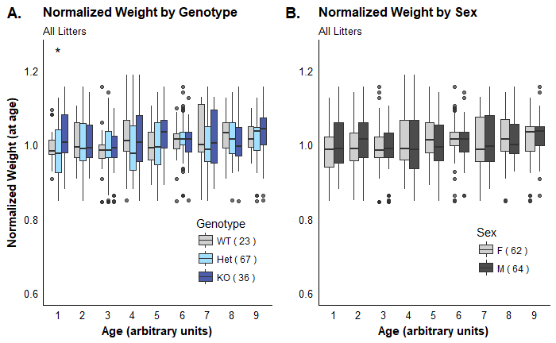

```r
#Boxplot Parameters for Norm Weight
xaxis <- "Age (arbitrary units)"
yaxis <- "Normalized Weight (at age)"
subtitle <- "All Litters"
ylim <- c(0.6,1.25)
#Boxplot of norm weight across age, divided by genotype
title <- "Normalized Weight by Genotype"
plotA <- bp(Data, x=Data$AgeFactor, y=Data$NormAtAgeWT, fill=Data$Geno,
                   xaxis, yaxis, ylim, title, subtitle, color_name = "Genotype",
                   colors = geno_colors, legend_lab = geno_lab, legend_pos = bottom_right)
#Boxplot of norm weight across age, divided by sex
title <- "Normalized Weight by Sex"
plotB <- bp(Data, x=Data$AgeFactor, y=Data$NormAtAgeWT, fill=Data$Sex,
                   xaxis, yaxis="", ylim, title, subtitle, color_name = "Sex",
                   colors = sex_colors, legend_lab = sex_lab, legend_pos = bottom_right)
#Boxplot of norm weight across age, divided by litter size
title <- "Normalized Weight by Litter Size"
plotC <- brewer_bp(Data, x=Data$AgeFactor, y=Data$NormAtAgeWT, fill=Data$LitterSize,
                   xaxis, yaxis, ylim, title, subtitle, color_name = "Litter Size",
                   legend_lab = LS_lab, legend_pos = "right")
#Arrange boxplots into 3 panels
suppressWarnings(ggarrange(plotA, plotB, labels = c("A.","B."), ncol = 2, nrow = 1))
```

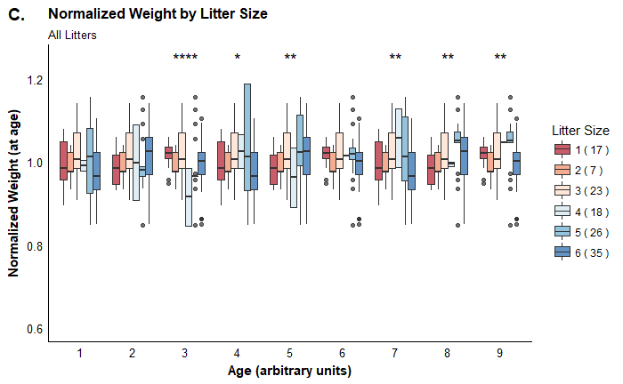

```r
suppressWarnings(ggarrange(plotC, labels = c("C."), ncol = 1, nrow = 1))
```

**Observations**

**Statistical Analyses**  
*Three Way Mixed Model ANOVA*  
*Response Variable: Normalized Weight (at age)*  
*Between Subjects Factors: Genotype, Sex*  
*Within Subjects Factors: Age*

```r
#Statistical analysis of normalized weight across age by genotype
model <- aov(Data$NormAtAgeWT ~Data$Geno*Data$Sex*Data$Age +
                    Error(Data$PupID/Data$Age)+Data$Geno*Data$Sex, data=Data)
summary(model)
```

```
Error: Data$PupID
                    Df Sum Sq  Mean Sq F value Pr(>F)
Data$Geno            2 0.0260 0.013020   3.401 0.0366 *
Data$Sex             1 0.0000 0.000044   0.011 0.9152
Data$Geno:Data$Sex   2 0.0163 0.008145   2.128 0.1236
Residuals          120 0.4593 0.003828
---
Signif. codes:  0 *** 0.001 ** 0.01 * 0.05 . 0.1   1

Error: Data$PupID:Data$Age
                             Df Sum Sq  Mean Sq F value  Pr(>F)
Data$Age                      8  0.098 0.012233   2.785 0.00474 **
Data$Geno:Data$Age           16  0.072 0.004477   1.019 0.43306
Data$Sex:Data$Age             8  0.044 0.005483   1.248 0.26741
Data$Geno:Data$Sex:Data$Age  16  0.096 0.005987   1.363 0.15237
Residuals                   960  4.217 0.004392
---
Signif. codes:  0 *** 0.001 ** 0.01 * 0.05 . 0.1   1
```

There are no significant interactions. There is a main effect of genotype (p = 0.037).

#### *Post-Hoc: Tukey’s Honestly Significant Difference - Genotype*

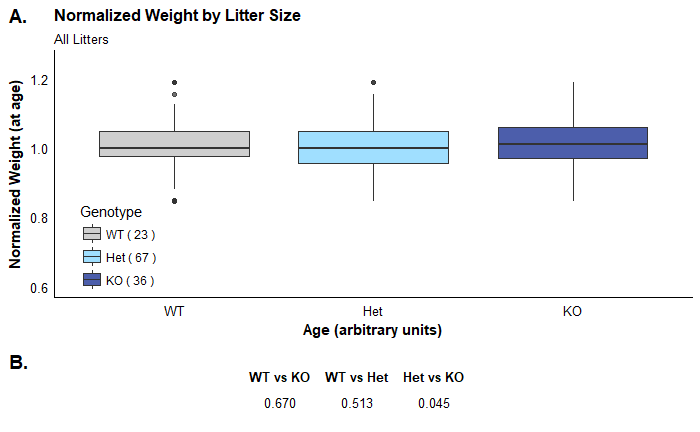

```r
#Posthoc TukeyHSD - Genotype at age 9
mod <- TukeyHSD(aov(Data$NormAtAgeWT ~Data$Geno, data = Data), ordered = TRUE)
Geno <- mod$`Data$Geno`
Het_KO <- Geno[2,4]
WT_KO <- Geno[3,4]
WT_Het <- Geno[1,4]
multicomp <- data.frame(WT_KO,WT_Het,Het_KO)
plotA <- bp(Data, x=Data$Geno, y=Data$NormAtAgeWT, fill=Data$Geno,
                   xaxis, yaxis, ylim, title, subtitle, color_name = "Genotype",
                   colors = geno_colors, legend_lab = geno_lab, legend_pos = c(0.1,0.2))
tableB <- ggtexttable(format(round(multicomp,3), nsmall = 3),
            cols = c("WT vs KO", "WT vs Het", "Het vs KO"),
            rows = c(""),
            theme = ttheme("blank", base_size = 10))
ggarrange(plotA, tableB, labels = c("A.","B."), ncol = 1, nrow = 2, heights = c(4,1))
```

Post-hoc analyses reveal that mutant mice (KO, *dark blue*) have significantly greater normalized weight than heterozygous mice (p = 0.045). There are no significant differences in normalized weight for any other group.

### 2.3.2 Normalized Length Across Age

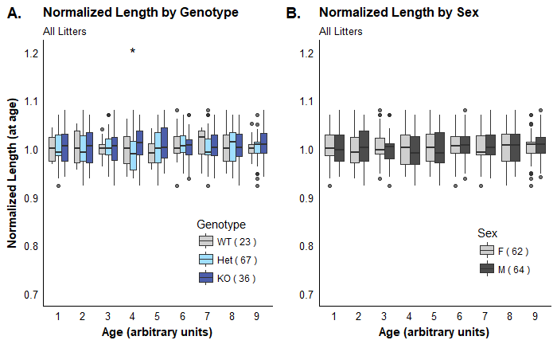

```r
#Boxplot Parameters for Norm Length
xaxis <- "Age (arbitrary units)"
yaxis <- "Normalized Length (at age)"
ylim <- c(0.7,1.2)
#Boxplot of norm Length across age, divided by genotype
title <- "Normalized Length by Genotype"
plotA <- bp(Data, x=Data$AgeFactor, y=Data$NormAtAgeLN, fill=Data$Geno,
                   xaxis, yaxis, ylim, title, subtitle, color_name = "Genotype",
                   colors = geno_colors, legend_lab = geno_lab, legend_pos = bottom_right)
#Boxplot of norm Length across age, divided by sex
title <- "Normalized Length by Sex"
plotB <- bp(Data, x=Data$AgeFactor, y=Data$NormAtAgeLN, fill=Data$Sex,
                   xaxis, yaxis="", ylim, title, subtitle, color_name = "Sex",
                   colors = sex_colors, legend_lab = sex_lab, legend_pos = bottom_right)
#Boxplot of norm Length across age, divided by litter size
title <- "Normalized Length by Litter Size"
plotC <- brewer_bp(Data, x=Data$AgeFactor, y=Data$NormAtAgeLN, fill=Data$LitterSize,
                   xaxis, yaxis, ylim, title, subtitle, color_name = "Litter Size",
                   legend_lab = LS_lab, legend_pos = "right")
#Arrange boxplots into 3 panels
suppressWarnings(ggarrange(plotA, plotB, labels = c("A.","B."), ncol = 2, nrow = 1))
```

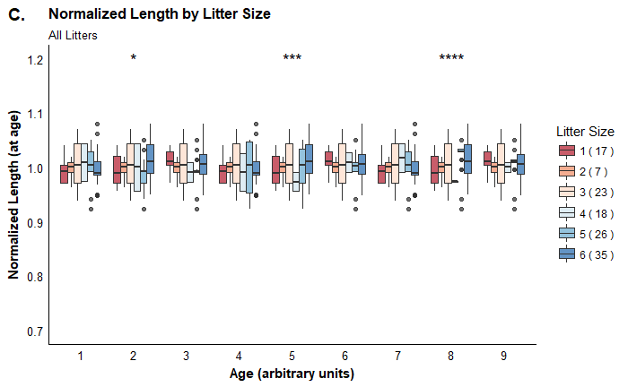

```r
suppressWarnings(ggarrange(plotC, labels = c("C."), ncol = 1, nrow = 1))
```

**Observations**

*Litter Size*  
Across most ages, there is no significantly effect of litter size on normalized length.

**Statistical Analyses**  
*Three Way Mixed Model ANOVA*  
*Response Variable: Normalized Length (at age)*  
*Between Subjects Factors: Genotype, Sex*  
*Within Subjects Factors: Age*

```r
#Statistical analysis of normalized length across age by genotype
model <- aov(Data$NormAtAgeLN ~Data$Geno*Data$Sex*Data$Age +
                    Error(Data$PupID/Data$Age)+Data$Geno*Data$Sex, data=Data)
summary(model)
```

```
Error: Data$PupID
                    Df  Sum Sq  Mean Sq F value Pr(>F)
Data$Geno            2 0.00551 0.002756   1.745  0.179
Data$Sex             1 0.00005 0.000049   0.031  0.861
Data$Geno:Data$Sex   2 0.00684 0.003421   2.167  0.119
Residuals          120 0.18948 0.001579

Error: Data$PupID:Data$Age
                             Df Sum Sq   Mean Sq F value Pr(>F)
Data$Age                      8 0.0051 0.0006373   0.639  0.746
Data$Geno:Data$Age           16 0.0127 0.0007925   0.794  0.693
Data$Sex:Data$Age             8 0.0057 0.0007175   0.719  0.675
Data$Geno:Data$Sex:Data$Age  16 0.0159 0.0009960   0.998  0.456
Residuals                   960 0.9579 0.0009978
```

There are no significantly effects of genotype, sex or age on mouse length (normalized at each age).

### 2.3.3 Normalized BMI Across Age

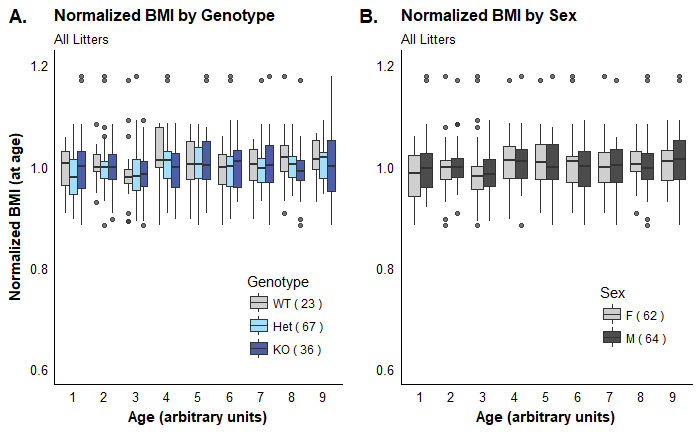

```r
#Boxplot Parameters for Norm BMI
xaxis <- "Age (arbitrary units)"
yaxis <- "Normalized BMI (at age)"
ylim <- c(0.6, 1.2)
#Boxplot of norm BMI across age, divided by genotype
title <- "Normalized BMI by Genotype"
plotA <- bp(Data, x=Data$AgeFactor, y=Data$NormAtAgeBMI, fill=Data$Geno,
                   xaxis, yaxis, ylim, title, subtitle, color_name = "Genotype",
                   colors = geno_colors, legend_lab = geno_lab, legend_pos = bottom_right)
#Boxplot of norm BMI across age, divided by sex
title <- "Normalized BMI by Sex"
plotB <- bp(Data, x=Data$AgeFactor, y=Data$NormAtAgeBMI, fill=Data$Sex,
                   xaxis, yaxis="", ylim, title, subtitle, color_name = "Sex",
                   colors = sex_colors, legend_lab = sex_lab, legend_pos = bottom_right)
#Boxplot of norm BMI across age, divided by litter size
title <- "Normalized BMI by Litter Size"
plotC <- brewer_bp(Data, x=Data$AgeFactor, y=Data$NormBMI, fill=Data$LitterSize,
                   xaxis, yaxis, ylim = c(0.7, 1.4), title, subtitle, color_name = "Litter Size",
                   legend_lab = LS_lab, legend_pos = "right")
#Arrange boxplots into 3 panels
suppressWarnings(ggarrange(plotA, plotB, labels = c("A.","B."), ncol = 2, nrow = 1))
```

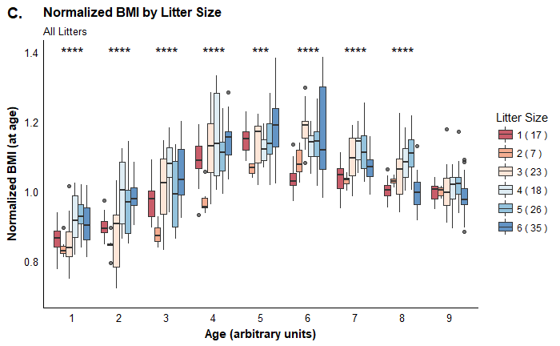

```r
suppressWarnings(ggarrange(plotC, labels = c("C."), ncol = 1, nrow = 1))
```

**Observations**

*Genotype and Sex*  
There are no significant differences in BMI (normalized at each age) between genotypes and between sexes.

*Litter Size*  
Surprisingly, there are significant differences in BMI (normalized at each age) between litter sizes for all ages except age 9. These differences may be due to a few outlier litters (ie. litters of size 1 and 2, which also have the lowest sample sizes).

**Statistical Analyses**  
*Three Way Mixed Model ANOVA*  
*Response Variable: Normalized BMI*  
*Between Subjects Factors: Genotype, Sex*  
*Within Subjects Factors: Age*

```r
#Statistical analysis of normalized length across age by genotype
model <- aov(Data$NormAtAgeBMI ~Data$Geno*Data$Sex*Data$Age +
                    Error(Data$PupID/Data$Age)+Data$Geno*Data$Sex, data=Data)
summary(model)
```

```
Error: Data$PupID
                    Df Sum Sq  Mean Sq F value Pr(>F)
Data$Geno            2 0.0042 0.002117   0.460  0.632
Data$Sex             1 0.0001 0.000062   0.013  0.908
Data$Geno:Data$Sex   2 0.0019 0.000957   0.208  0.813
Residuals          120 0.5522 0.004602

Error: Data$PupID:Data$Age
                             Df Sum Sq  Mean Sq F value   Pr(>F)
Data$Age                      8 0.0723 0.009040   4.729 1.05e-05 ***
Data$Geno:Data$Age           16 0.0318 0.001987   1.040    0.411
Data$Sex:Data$Age             8 0.0144 0.001797   0.940    0.482
Data$Geno:Data$Sex:Data$Age  16 0.0174 0.001088   0.569    0.908
Residuals                   960 1.8351 0.001912
---
Signif. codes:  0 *** 0.001 ** 0.01 * 0.05 . 0.1   1
```

Normalized BMI (at age) is not different between genotypes and sexes. There is a strong effect of age, however, which is likely due to the way in which the data were normalized.

### 2.3.4 Normalized Weight Gain, Normalized Length Gain and Normalized BMI Across Litter Size

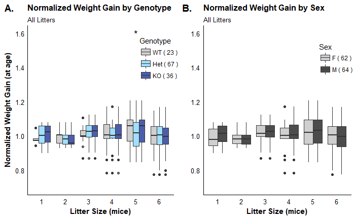

```r
#Boxplot Parameters for Normalized Weight Gain
xaxis <- "Litter Size (mice)"
yaxis <- "Normalized Weight Gain (at age)"
ylim <- c(0.7,1.6)
#Boxplot of norm weight gain across age, divided by genotype
title <- "Normalized Weight Gain by Genotype"
plotA <- bp(Data, x=Data$LitterSize, y=Data$NormAtAgeWTGain, fill=Data$Geno,
                   xaxis, yaxis, ylim, title, subtitle, color_name = "Genotype",
                   colors = geno_colors, legend_lab = geno_lab, legend_pos = top_right)
#Boxplot of norm weight gain across age, divided by sex
title <- "Normalized Weight Gain by Sex"
plotB <- bp(Data, x=Data$LitterSize, y=Data$NormAtAgeWTGain, fill=Data$Sex,
                   xaxis, yaxis="", ylim, title, subtitle, color_name = "Sex",
                   colors = sex_colors, legend_lab = sex_lab, legend_pos = top_right)
#Boxplot Parameters - Boxplots for Length Gain
yaxis <- "Normalized Length Gain (at age)"
ylim <- c(0.7,1.4)
#Boxplot of norm length gain across age, divided by genotype
title <- "Normalized Length Gain by Genotype"
plotC <- bp(Data, x=Data$LitterSize, y=Data$NormAtAgeLNGain, fill=Data$Geno,
                   xaxis, yaxis, ylim, title, subtitle, color_name = "Genotype",
                   colors = geno_colors, legend_lab = geno_lab, legend_pos = top_right)
#Boxplot of norm length gain across age, divided by sex
title <- "Normalized Length Gain by Sex"
plotD <- bp(Data, x=Data$LitterSize, y=Data$NormAtAgeLNGain, fill=Data$Sex,
                   xaxis, yaxis="", ylim, title, subtitle, color_name = "Sex",
                   colors = sex_colors, legend_lab = sex_lab, legend_pos = top_right)
suppressWarnings(ggarrange(plotA, plotB, labels = c("A.","B."), ncol = 2, nrow = 1))
```

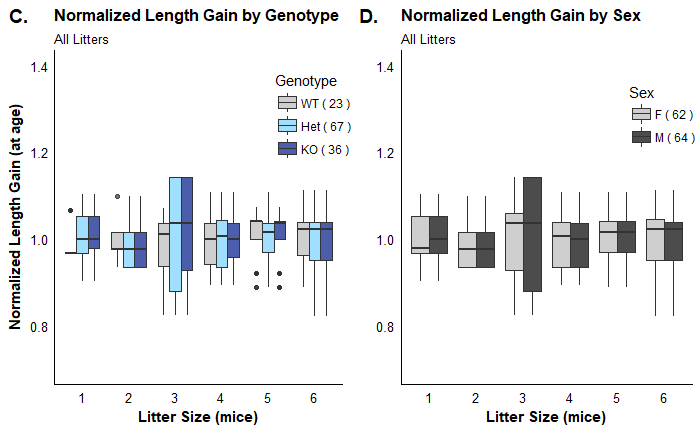

```r
suppressWarnings(ggarrange(plotC, plotD, labels = c("C.","D."), ncol = 2, nrow = 1))
```

**Observations**  
There appears to be no effect of either genotype or sex on normalized weight gain and length gain when normalized at each age.

### 2.3.5 Statistical Analysis of Normalized Weight Gain

*Two Way ANOVA*  
*Response Variable: Normalized Weight Gain (at age)*  
*Between Subjects Factors: Genotype, Sex*

```r
#Statistical analysis of normalized weight gain by genotype and sex
model <- aov(Data$NormAtAgeWTGain ~Data$Geno*Data$Sex, data=Data)
summary(model)
```

```
                     Df Sum Sq  Mean Sq F value Pr(>F)
Data$Geno             2  0.029 0.014419   2.181 0.1134
Data$Sex              1  0.001 0.001471   0.223 0.6372
Data$Geno:Data$Sex    2  0.032 0.015910   2.406 0.0906 .
Residuals          1128  7.458 0.006611
---
Signif. codes:  0 *** 0.001 ** 0.01 * 0.05 . 0.1   1
```

Statistics confirm that there are no differences between genotypes and sexes for normalized weight gain